# Marketing Analytics - Trabalho Final

Authors

Michel Maurice Conjaud

Hélio Pereira Oliveira

Renan Cabral

Tiago Evangelista Pardo

# Projeto Final Marketing Analytics

Vamos analisar uma base de Marketing para uma campanha de promoção 2 por 1 (BOGO - Buy one get one).

Buscamos entender os efeitos da campanha sobre a conversão de vendas e minimização dos custos da campanha.

Base de dados:

https://www.kaggle.com/datasets/davinwijaya/customer-retention

(A base é fictícia e foi criada para treinamento de análises e modelos preditivos)

Temos duas campanhas de marketing:

- Uma campanha de marketing para a promoção de desconto;
- Uma campanha de marketing para a promoção de “Buy one get one” (BOGO).

Vamos buscar entender sua eficácia e qual possui melhor desempenho.

```r
vendas <- read.csv("data.csv")
```

Exploração Inicial da Base:

- **recency**: Número de meses desde a última compra do cliente.
- **history**: Valor total gasto pelo cliente até agora.
- **used_discount**: Indica se o cliente usou um cupom de desconto em compras anteriores (1 para sim, 0 para não).
- **used_bogo**: Indica se o cliente utilizou uma promoção do tipo “compre um, leve outro” (BOGO) em compras anteriores (1 - para sim, 0 para não).
- **zip_code**: Categoria do código postal do cliente (Surburban, Rural, Urban).
- **is_referral**: Indica se o cliente foi referido por outro cliente (1 para sim, 0 para não).
- **channel**: Canal pelo qual o cliente realizou a última compra (Phone, Web).
- **offer**: Tipo de oferta que foi enviada ao cliente (Buy One Get One, No Offer, Discount).
- **conversion**: Indica se a campanha de marketing resultou em uma conversão/purchase (1 para sim, 0 para não).

```r
vendas %>% head()
```

```
  recency history used_discount used_bogo  zip_code is_referral channel
1      10  142.44             1         0 Surburban           0   Phone
2       6  329.08             1         1     Rural           1     Web
3       7  180.65             0         1 Surburban           1     Web
4       9  675.83             1         0     Rural           1     Web
5       2   45.34             1         0     Urban           0     Web
6       6  134.83             0         1 Surburban           0   Phone
            offer conversion
1 Buy One Get One          0
2        No Offer          0
3 Buy One Get One          0
4        Discount          0
5 Buy One Get One          0
6 Buy One Get One          1
```

## Vamos analisar a distribuição das características dos clientes:

Análise demográfica - Temos apenas 2 características demográficas: ‘zip_code’ e ‘channel’.

(Obs.: Além das características demográficas precismamos analisar também outras características do cliente como a recência, o histórico (total gasto) e se o cliente foi referido)

### Distribuição por zona (zip code):

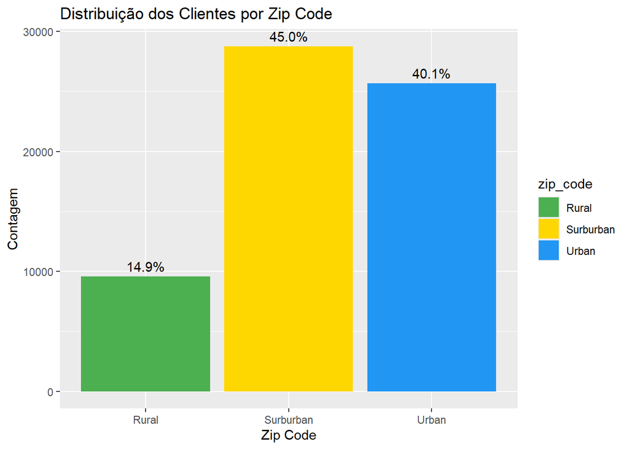

```r
# Gráfico de barras para 'zip_code'
gg_zip_code <- vendas %>%
  ggplot(aes(x = zip_code, fill = zip_code)) +
  geom_bar() +
  labs(title = "Distribuição dos Clientes por Zip Code",
       x = "Zip Code",
       y = "Contagem") +
  scale_fill_manual(values = c("Surburban" = "#FFD700", "Rural" = "#4CAF50", "Urban" = "#2196F3"))

gg_zip_code <- add_percentages(gg_zip_code, vendas)
print(gg_zip_code)
```

### Distribuição por canal de compra:

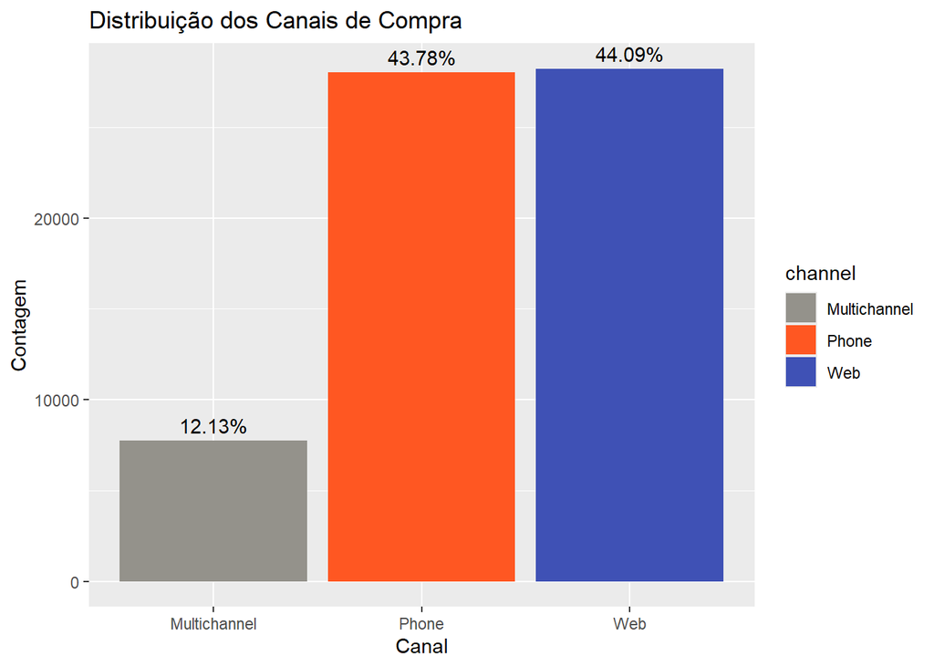

```r
# Gráfico de barras para 'channel'
gg_channel <- vendas %>%
  ggplot(aes(x = channel, fill = channel)) +
  geom_bar() +
  labs(title = "Distribuição dos Canais de Compra",
       x = "Canal",
       y = "Contagem") +
  scale_fill_manual(values = c("Phone" = "#FF5722", "Web" = "#3F51B5", "Multichannel" = "#94928b"))

gg_channel <- add_percentages(gg_channel, vendas)
print(gg_channel)
```

### Distribuição por tipo de oferta:

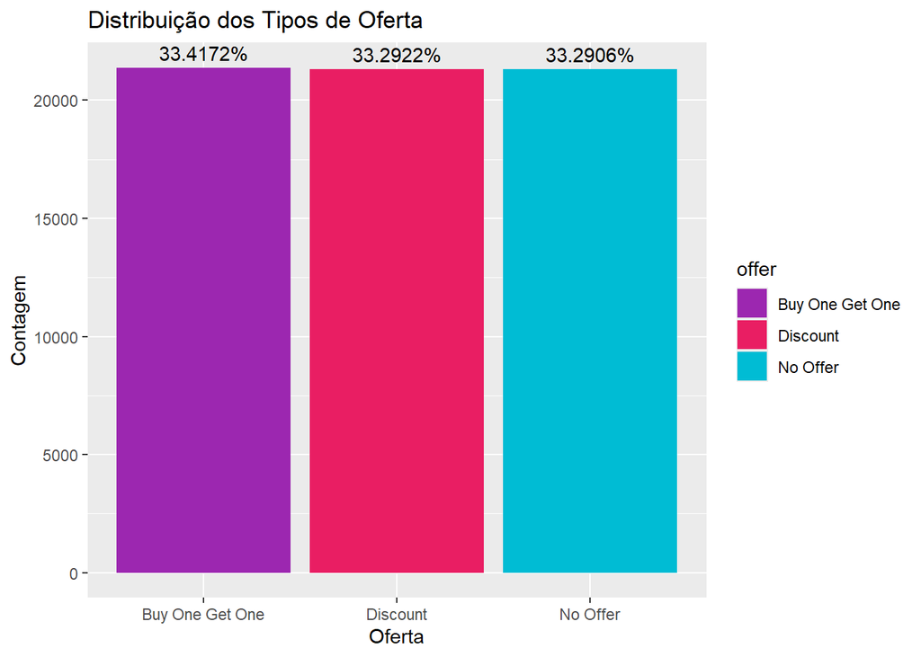

```r
# Gráfico de barras para 'offer'
gg_offer <- vendas %>%
  ggplot(aes(x = offer, fill = offer)) +
  geom_bar() +
  labs(title = "Distribuição dos Tipos de Oferta",
       x = "Oferta",
       y = "Contagem") +
  scale_fill_manual(values = c("Buy One Get One" = "#9C27B0", "No Offer" = "#00BCD4", "Discount" = "#E91E63"))

gg_offer <- add_percentages(gg_offer, vendas)
print(gg_offer)
```

Vemos que a distribuição das amostras está distribuída igualmente entre os 3 tipos de oferta (BOGO, No Offer, Discount).

### Distribuição demográfica por tipo de oferta:

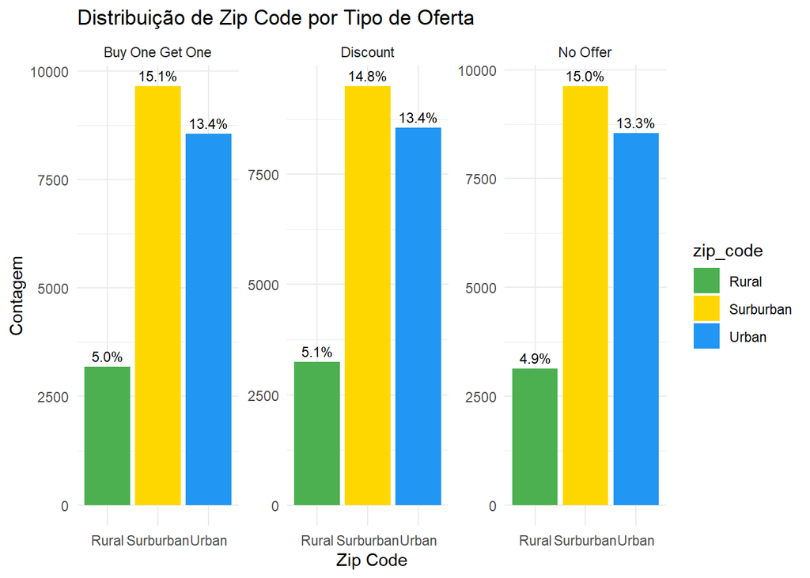

```r
# Gráfico de barras para 'zip_code' por cada grupo de 'offer'
gg_zip_offer <- vendas %>%
  ggplot(aes(x = zip_code, fill = zip_code)) +
  geom_bar(position = position_dodge()) +
  facet_wrap(~ offer, scales = "free_y") + # Cada painel representa um tipo de oferta
  labs(title = "Distribuição de Zip Code por Tipo de Oferta",
       x = "Zip Code",
       y = "Contagem") +
  scale_fill_manual(values = c("Surburban" = "#FFD700", "Rural" = "#4CAF50", "Urban" = "#2196F3")) +
  theme_minimal()

# Adicionando porcentagens aos gráficos
gg_zip_offer <- gg_zip_offer +
  geom_text(stat = 'count', aes(label = scales::percent(..count../sum(..count..), accuracy = 0.1)),
            position = position_dodge(width = 0.9), vjust = -0.5, size = 3)

print(gg_zip_offer)
```

Verificamos que a distribuição de ‘Área’ é similar entre os grupos de oferta. Logo esse fator n deve afetar a amostragem.

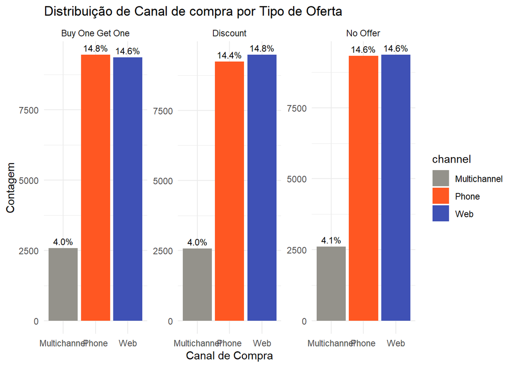

```r
# Gráfico de barras para 'channel' por cada grupo de 'offer'
gg_zip_offer <- vendas %>%
  ggplot(aes(x = channel, fill = channel)) +
  geom_bar(position = position_dodge()) +
  facet_wrap(~ offer, scales = "free_y") + # Cada painel representa um tipo de oferta
  labs(title = "Distribuição de Canal de compra por Tipo de Oferta",
       x = "Canal de Compra",
       y = "Contagem") +
  scale_fill_manual(values = c("Phone" = "#FF5722", "Web" = "#3F51B5", "Multichannel" = "#94928b")) +
  theme_minimal()

# Adicionando porcentagens aos gráficos
gg_zip_offer <- gg_zip_offer +
  geom_text(stat = 'count', aes(label = scales::percent(..count../sum(..count..), accuracy = 0.1)),
            position = position_dodge(width = 0.9), vjust = -0.5, size = 3)

print(gg_zip_offer)
```

Assim como a área a distribuição de ‘Canal de Compra’ é similar entre os grupos de oferta e não deve afetar a análise dos efeitos da campanha.

## Análise dos efeitos da Campanha

Vamos agora analisar os efeitos em conversão entre campanhas e grupo de controle

### Teste A/B:

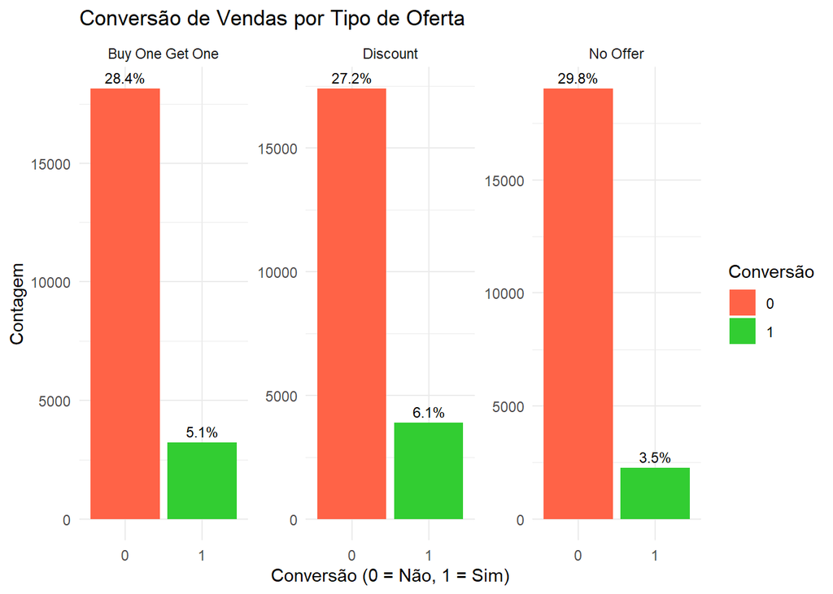

```r
# Gráfico de barras para 'conversion' por cada grupo de 'offer', com o eixo x representando apenas conversão
gg_conversion_offer <- vendas %>%
  ggplot(aes(x = as.factor(conversion), fill = as.factor(conversion))) +
  geom_bar(position = position_dodge()) +
  facet_wrap(~ offer, scales = "free_y") + # Cada painel representa um tipo de oferta
  labs(title = "Conversão de Vendas por Tipo de Oferta",
       x = "Conversão (0 = Não, 1 = Sim)",
       y = "Contagem",
       fill = "Conversão") +
  scale_fill_manual(values = c("0" = "#FF6347", "1" = "#32CD32")) + # Cores para não conversão e conversão
  theme_minimal()

# Adicionando porcentagens aos gráficos
gg_conversion_offer <- gg_conversion_offer +
  geom_text(stat = 'count', aes(label = scales::percent(..count../sum(..count..), accuracy = 0.1)),
            position = position_dodge(width = 0.9), vjust = -0.5, size = 3)

print(gg_conversion_offer)
```

Validamos assim via teste A/B que ambas as campanhas de marketing (BOGO e Discount) tiveram um efeito positivo na conversão de vendas.

```r
# Calcular a taxa de conversão para cada grupo de oferta
conversion_rates <- vendas %>%
  group_by(offer) %>%
  summarise(conversion_rate = mean(conversion)*100) %>%
  ungroup()

# Encontrar a taxa de conversão do grupo de controle (No Offer)
control_rate <- conversion_rates %>%
  filter(offer == "No Offer") %>%
  pull(conversion_rate)

# Calcular o aumento de vendas para cada uma das campanhas em relação ao grupo de controle
conversion_increase <- conversion_rates %>%
  mutate(increase = ifelse(offer == "No Offer", NA, (conversion_rate - control_rate) / control_rate * 100))

# Mostrar os resultados, incluindo o grupo de controle
conversion_increase
```

```
# A tibble: 3 × 3
  offer           conversion_rate increase
  <chr>                     <dbl>    <dbl>
1 Buy One Get One            15.1     42.6
2 Discount                   18.3     72.1
3 No Offer                   10.6     NA
```

Verificamos um aumento de 72% na taxa de conversão para campanha de descontos e 42% para a campanha BOGO em relação ao grupo de controle.

Temos assim uma indicação inicial de que a campanha de BOGO pode não ser tão eficas para a conversão quanto um desconto tradicional.

Porém precisamos analisar agora se apesar do menor impacto absoluto qual das campanhas apresenta maior potencial de uplift.

Assim qual o efeito das campanhas de acordo com a população exposta.

### Vamos agora separar a base de acordo com os tratamentos para podermos realizar algumas análises individuais:

- BOGO (Buy One Get One)
- Discount (Desconto)

```r
vendas_bogo <- vendas %>%
  filter(offer == "Buy One Get One" | offer == "No Offer")  # Apenas BOGO e grupo de controle

vendas_discount <- vendas %>%
  filter(offer == "Discount" | offer == "No Offer")  # Apenas Discount e grupo de controle
```

### Modelos Uplift:

#### Preparando as bases de dados para os conjuntos das 2 campanhas:

- Transformamos as variáveis qualitativas em dummies (One-hot enconding)
- Criamos uma variável “flag” para casos de tratamento
- Removemos as variáveis que poderiam causar algum data leak no modelo.

```r
uplift_data_bogo <- vendas_bogo %>%
  mutate(
    channel = as.factor(channel),
    zip_code = as.factor(zip_code),
    treat = ifelse(offer == "No Offer", 0, 1),  # Indicador de tratamento binário
  ) %>%
  model.matrix(~ channel + zip_code + treat - 1, data = .) %>%
  as.data.frame() %>%
  cbind(vendas_bogo, .) %>%
  select(-c(channel, zip_code, offer))  # Removendo as colunas originais categóricas
```

```r
uplift_data_discount <- vendas_discount %>%
  mutate(
    channel = as.factor(channel),
    zip_code = as.factor(zip_code),
    treat = ifelse(offer == "No Offer", 0, 1),  # Indicador de tratamento binário
  ) %>%
  model.matrix(~ channel + zip_code + treat - 1, data = .) %>%
  as.data.frame() %>%
  cbind(vendas_discount, .) %>%
  select(-c(channel, zip_code, offer))  # Removendo as colunas originais categóricas
```

```r
head(uplift_data)
```

[output not shown]

Separando as bases em treinamento e teste:

```r
#Vamos separar a base em treinamento e teste para os modelos uplift:
set.seed(123)

split_uplift_bogo <- SplitUplift(data = uplift_data_bogo, p = 0.8, group = c("treat", "conversion"))
split_uplift_discount <- SplitUplift(data = uplift_data_discount, p = 0.8, group = c("treat", "conversion"))

uplift_treinamento_bogo <- split_uplift_bogo[[1]]
uplift_test_bogo <- split_uplift_bogo[[2]]

uplift_treinamento_discount <- split_uplift_discount[[1]]
uplift_test_discount <- split_uplift_discount[[2]]
```

Definindo as variaveis preditoras:

```r
#Definindo variáveis preditoras:

predictors_bogo <- setdiff(names(uplift_treinamento_bogo), c("conversion", "treat"))
predictors_discount <- setdiff(names(uplift_treinamento_discount), c("conversion", "treat"))
```

#### Modelo Uplift: Two-model estimator

```r
dual_uplift_model_bogo <- DualUplift(
  data = uplift_treinamento_bogo,  # fornecendo a base de dados
  treat = 'treat',  # especificando a coluna de tratamento
  outcome = 'conversion',  # especificando a variável de resultado
  predictors = predictors_bogo  # fornecendo a lista de preditores
)

dual_uplift_model_discount <- DualUplift(
  data = uplift_treinamento_discount,  # fornecendo a base de dados
  treat = 'treat',  # especificando a coluna de tratamento
  outcome = 'conversion',  # especificando a variável de resultado
  predictors = predictors_discount  # fornecendo a lista de preditores
)
```

Vamos analisar os resultados dos modelos para as duas campanhas:

1. Campanha BOGO:

```r
#Análise dos resultados do modelo BOGO:
print(summary(dual_uplift_model_bogo))
```

```
$call
DualUplift(data = uplift_treinamento_bogo, treat = "treat", outcome = "conversion",
    predictors = predictors_bogo)

$control

Call:
"Control Group Logistic Model"

Coefficients: (1 not defined because of singularities)
                      Estimate Std. Error z value Pr(>|z|)
(Intercept)         -1.5854108  0.1112746 -14.248  < 2e-16 ***
recency             -0.0720857  0.0076345  -9.442  < 2e-16 ***
history              0.0006615  0.0001101   6.008 1.87e-09 ***
used_discount        0.5434398  0.0810094   6.708 1.97e-11 ***
used_bogo            0.4996572  0.0807016   6.191 5.96e-10 ***
is_referral         -0.7785105  0.0551787 -14.109  < 2e-16 ***
channelMultichannel -0.1845251  0.0804808  -2.293   0.0219 *
channelPhone        -0.3376019  0.0548164  -6.159 7.33e-10 ***
channelWeb                  NA         NA      NA       NA
zip_codeSurburban   -0.4559637  0.0682914  -6.677 2.44e-11 ***
zip_codeUrban       -0.5084169  0.0698971  -7.274 3.50e-13 ***
---
Signif. codes:  0 '***' 0.001 '**' 0.01 '*' 0.05 '.' 0.1 ' ' 1

(Dispersion parameter for binomial family taken to be 1)

    Null deviance: 11666  on 17064  degrees of freedom
Residual deviance: 11160  on 17055  degrees of freedom
AIC: 11180

Number of Fisher Scoring iterations: 5


$treatment

Call:
"Treatment Group Logistic Model"

Coefficients: (1 not defined because of singularities)
```

[output cut: 11 more lines]

```
zip_codeUrban       -2.860e-01  6.289e-02  -4.548 5.42e-06 ***
---
Signif. codes:  0 '***' 0.001 '**' 0.01 '*' 0.05 '.' 0.1 ' ' 1

(Dispersion parameter for binomial family taken to be 1)

    Null deviance: 14588  on 17088  degrees of freedom
Residual deviance: 14122  on 17079  degrees of freedom
AIC: 14142

Number of Fisher Scoring iterations: 4


attr(,"class")
[1] "summary.DualUplift"
```

2. campanha Discount:

```r
#Análise dos resultados do modelo Discount:
print(summary(dual_uplift_model_discount))
```

```
$call
DualUplift(data = uplift_treinamento_discount, treat = "treat",
    outcome = "conversion", predictors = predictors_discount)

$control

Call:
"Control Group Logistic Model"

Coefficients: (1 not defined because of singularities)
                      Estimate Std. Error z value Pr(>|z|)
(Intercept)         -1.6483136  0.1109360 -14.858  < 2e-16 ***
recency             -0.0683778  0.0076895  -8.892  < 2e-16 ***
history              0.0006766  0.0001090   6.208 5.36e-10 ***
used_discount        0.5776023  0.0800113   7.219 5.24e-13 ***
used_bogo            0.5977803  0.0799939   7.473 7.85e-14 ***
is_referral         -0.7731149  0.0555312 -13.922  < 2e-16 ***
channelMultichannel -0.2073174  0.0811432  -2.555   0.0106 *
channelPhone        -0.3560512  0.0551138  -6.460 1.04e-10 ***
channelWeb                  NA         NA      NA       NA
zip_codeSurburban   -0.5079599  0.0680896  -7.460 8.64e-14 ***
zip_codeUrban       -0.5566924  0.0696134  -7.997 1.28e-15 ***
---
Signif. codes:  0 '***' 0.001 '**' 0.01 '*' 0.05 '.' 0.1 ' ' 1

(Dispersion parameter for binomial family taken to be 1)

    Null deviance: 11560  on 16986  degrees of freedom
Residual deviance: 11032  on 16977  degrees of freedom
AIC: 11052

Number of Fisher Scoring iterations: 5


$treatment

Call:
"Treatment Group Logistic Model"

Coefficients: (1 not defined because of singularities)
```

[output cut: 11 more lines]

```
zip_codeUrban       -3.410e-01  5.754e-02  -5.927 3.09e-09 ***
---
Signif. codes:  0 '***' 0.001 '**' 0.01 '*' 0.05 '.' 0.1 ' ' 1

(Dispersion parameter for binomial family taken to be 1)

    Null deviance: 16180  on 17102  degrees of freedom
Residual deviance: 15700  on 17093  degrees of freedom
AIC: 15720

Number of Fisher Scoring iterations: 4


attr(,"class")
[1] "summary.DualUplift"
```

#### Modelo Uplift: Interaction estimator

```r
inter_uplift_model_bogo <- InterUplift(
  data = uplift_treinamento_bogo,  # fornecendo a base de dados
  treat = 'treat',  # especificando a coluna de tratamento
  outcome = 'conversion',  # especificando a variável de resultado
  predictors = predictors_bogo  # fornecendo a lista de preditores
)

inter_uplift_model_discount <- InterUplift(
  data = uplift_treinamento_discount,  # fornecendo a base de dados
  treat = 'treat',  # especificando a coluna de tratamento
  outcome = 'conversion',  # especificando a variável de resultado
  predictors = predictors_discount  # fornecendo a lista de preditores
)
```

Vamos avaliar os modelos construídos:

1. Campanha BOGO:

```r
print(summary(inter_uplift_model_bogo))
```

```
Call:
InterUplift(data = uplift_treinamento_bogo, treat = "treat",
    outcome = "conversion", predictors = predictors_bogo)

Coefficients: (2 not defined because of singularities)
                            Estimate Std. Error z value Pr(>|z|)
(Intercept)               -1.5854108  0.1112746 -14.248  < 2e-16 ***
treat                     -0.1635446  0.1494095  -1.095 0.273689
recency                   -0.0720857  0.0076345  -9.442  < 2e-16 ***
history                    0.0006615  0.0001101   6.008 1.87e-09 ***
used_discount              0.5434398  0.0810094   6.708 1.97e-11 ***
used_bogo                  0.4996572  0.0807016   6.191 5.96e-10 ***
is_referral               -0.7785105  0.0551787 -14.109  < 2e-16 ***
channelMultichannel       -0.1845251  0.0804808  -2.293 0.021860 *
channelPhone              -0.3376019  0.0548164  -6.159 7.33e-10 ***
channelWeb                        NA         NA      NA       NA
zip_codeSurburban         -0.4559637  0.0682914  -6.677 2.44e-11 ***
zip_codeUrban             -0.5084169  0.0698971  -7.274 3.50e-13 ***
treat:recency              0.0276764  0.0100010   2.767 0.005651 **
treat:history             -0.0002070  0.0001452  -1.425 0.154040
treat:used_discount       -0.1744720  0.1067682  -1.634 0.102234
treat:used_bogo            0.3755420  0.1083120   3.467 0.000526 ***
treat:is_referral          0.3113335  0.0716230   4.347 1.38e-05 ***
treat:channelMultichannel  0.0471856  0.1072382   0.440 0.659932
treat:channelPhone         0.0873720  0.0720261   1.213 0.225107
treat:channelWeb                  NA         NA      NA       NA
treat:zip_codeSurburban    0.2263884  0.0918314   2.465 0.013691 *
treat:zip_codeUrban        0.2223966  0.0940283   2.365 0.018020 *
---
Signif. codes:  0 '***' 0.001 '**' 0.01 '*' 0.05 '.' 0.1 ' ' 1

(Dispersion parameter for binomial family taken to be 1)

    Null deviance: 26405  on 34153  degrees of freedom
Residual deviance: 25282  on 34134  degrees of freedom
AIC: 25322

Number of Fisher Scoring iterations: 5
```

2. Campanha Discount:

```r
print(summary(inter_uplift_model_discount))
```

```
Call:
InterUplift(data = uplift_treinamento_discount, treat = "treat",
    outcome = "conversion", predictors = predictors_discount)

Coefficients: (2 not defined because of singularities)
                            Estimate Std. Error z value Pr(>|z|)
(Intercept)               -1.6483136  0.1109360 -14.858  < 2e-16 ***
treat                      0.1596351  0.1436537   1.111 0.266461
recency                   -0.0683778  0.0076895  -8.892  < 2e-16 ***
history                    0.0006766  0.0001090   6.208 5.36e-10 ***
used_discount              0.5776023  0.0800113   7.219 5.24e-13 ***
used_bogo                  0.5977803  0.0799939   7.473 7.85e-14 ***
is_referral               -0.7731149  0.0555312 -13.922  < 2e-16 ***
channelMultichannel       -0.2073174  0.0811432  -2.555 0.010620 *
channelPhone              -0.3560512  0.0551138  -6.460 1.04e-10 ***
channelWeb                        NA         NA      NA       NA
zip_codeSurburban         -0.5079599  0.0680896  -7.460 8.64e-14 ***
zip_codeUrban             -0.5566924  0.0696134  -7.997 1.28e-15 ***
treat:recency              0.0165794  0.0097555   1.699 0.089227 .
treat:history             -0.0002494  0.0001404  -1.777 0.075543 .
treat:used_discount        0.1164329  0.1033059   1.127 0.259713
treat:used_bogo            0.0930146  0.1032760   0.901 0.367779
treat:is_referral          0.2700231  0.0700178   3.856 0.000115 ***
treat:channelMultichannel  0.0604472  0.1053626   0.574 0.566167
treat:channelPhone         0.1658199  0.0701904   2.362 0.018156 *
treat:channelWeb                  NA         NA      NA       NA
treat:zip_codeSurburban    0.1570003  0.0885722   1.773 0.076300 .
treat:zip_codeUrban        0.2156858  0.0903130   2.388 0.016931 *
---
Signif. codes:  0 '***' 0.001 '**' 0.01 '*' 0.05 '.' 0.1 ' ' 1

(Dispersion parameter for binomial family taken to be 1)

    Null deviance: 28123  on 34089  degrees of freedom
Residual deviance: 26732  on 34070  degrees of freedom
AIC: 26772

Number of Fisher Scoring iterations: 5
```

### Vamos realizar as predições e salvar os resultados para análise uplift das campanhas:

```r
#Vamos realizar as predições com os modelos gerados para analisar o resultado:
set.seed(123)

#Predições de modelos Dual Uplift:

predicoes_dual_uplift_bogo <- predict.DualUplift(
  dual_uplift_model_bogo,
  newdata= uplift_test_bogo
  )

predicoes_dual_uplift_discount <- predict.DualUplift(
  dual_uplift_model_discount,
  newdata= uplift_test_discount
  )

#Predições de modelos Inter Uplift:

predicoes_inter_bogo <- predict.InterUplift(
  inter_uplift_model_bogo,
  newdata= uplift_test_bogo,
  treat = "treat"
  )

predicoes_inter_discount <- predict.InterUplift(
  inter_uplift_model_discount,
  newdata= uplift_test_discount,
  treat = "treat"
  )
```

Salvando os resultados:

```r
#Salvando os resultados de predição:

#uplift_teste$predito_dual_uplift <- predicoes_dual_uplift

uplift_test_bogo$predito_dual_uplift <- predicoes_dual_uplift_bogo
uplift_test_discount$predito_dual_uplift <- predicoes_dual_uplift_discount

uplift_test_bogo$predito_inter_uplift <- predicoes_inter_bogo
uplift_test_discount$predito_inter_uplift <- predicoes_inter_discount
```

### Vamos por fim analisar a performance dos modelos após realizar as predições:

```r
#Performance de modelos Dual Uplift:

performance_dual_uplift_bogo <- PerformanceUplift(
  data = uplift_test_bogo,
  treat = "treat",
  outcome = "conversion",
  prediction="predito_dual_uplift",
  nb.group = 30
  )

performance_dual_uplift_discount <- PerformanceUplift(
  data = uplift_test_discount,
  treat = "treat",
  outcome = "conversion",
  prediction="predito_dual_uplift",
  nb.group = 30
  )

#Performance de modelos Inter Uplift:

performance_inter_uplift_bogo <- PerformanceUplift(
  data = uplift_test_bogo,
  treat = "treat",
  outcome = "conversion",
  prediction="predito_inter_uplift",
  nb.group = 30
  )

performance_inter_uplift_discount <- PerformanceUplift(
  data = uplift_test_discount,
  treat = "treat",
  outcome = "conversion",
  prediction="predito_inter_uplift",
  nb.group = 30
  )
```

### Curva de QINI:

(Atenção aos valores dos eixos - campanhas de desconto tem um valor máximo maior)

```r
# Configurar a área de plotagem para 4 gráficos (2x2)
par(mfrow=c(2,2))

# Plotar cada gráfico de uplift
# Uplift Dual BOGO
plot(performance_dual_uplift_bogo, type = "b", lwd = 1, col="blue4", main="Dual Uplift - BOGO")
```

```
[1] 0.7846182
```

```r
# Uplift Dual Discount
plot(performance_dual_uplift_discount, type = "b", lwd = 1, col="red4", main="Dual Uplift - Discount")
```

```
[1] 0.4608461
```

```r
# Uplift Inter BOGO
plot(performance_inter_uplift_bogo, type = "b", lwd = 1, col="blue4", main="Inter Uplift - BOGO")
```

```
[1] 0.7846182
```

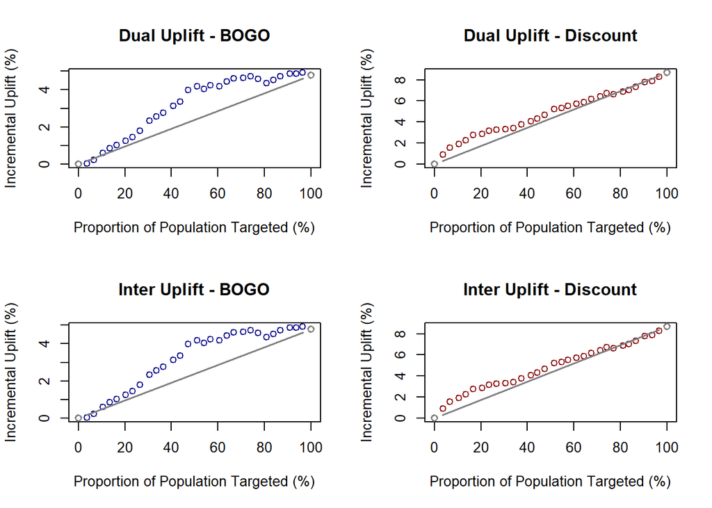

```
[1] 0.4608461
```

```r
# Uplift Inter Discount
plot(performance_inter_uplift_discount, type = "b", lwd = 1, col="red4", main="Inter Uplift - Discount")
```

```r
# Restaurar configuração padrão do par
par(mfrow=c(1,1))
```

#### Avaliando a área de QINI:

```r
# Cálculo da Área Qini para cada modelo
qini_bogo_dual <- round(QiniArea(performance_dual_uplift_bogo, adjusted=TRUE), 2)
qini_discount_dual <- round(QiniArea(performance_dual_uplift_discount, adjusted=TRUE), 2)
qini_bogo_inter <- round(QiniArea(performance_inter_uplift_bogo, adjusted=TRUE), 2)
qini_discount_inter <- round(QiniArea(performance_inter_uplift_discount, adjusted=TRUE), 2)

# Criando uma tabela para mostrar os valores
qini_results <- data.frame(
  Model = c("Dual Uplift BOGO", "Dual Uplift Discount", "Inter Uplift BOGO", "Inter Uplift Discount"),
  Qini_Area = c(qini_bogo_dual, qini_discount_dual, qini_bogo_inter, qini_discount_inter)
)

# Imprimindo a tabela com os valores da área Qini
print(qini_results)
```

```
                  Model Qini_Area
1      Dual Uplift BOGO      0.28
2  Dual Uplift Discount      0.05
3     Inter Uplift BOGO      0.28
4 Inter Uplift Discount      0.05
```

Os modelos Two-model (Dual) e o Interaction (Inter) apresentaram resultados iguais entre si em termos de desempenho de Qini.

Desta forma podemos seguir com qualquer um deles para maiores análises, vamos seguir com o Inter por ser no geral mais robusto.

## Comparação das Campanhas:

```r
# Configurando a área de plotagem para dois gráficos lado a lado
par(mfrow=c(1,2))

# Plotar o gráfico de Qini para a campanha BOGO usando o modelo Inter Uplift
plot(performance_inter_uplift_bogo, type = "l", lwd = 2, col="blue", main="Qini - BOGO Campaign")
```

```
[1] 0.7846182
```

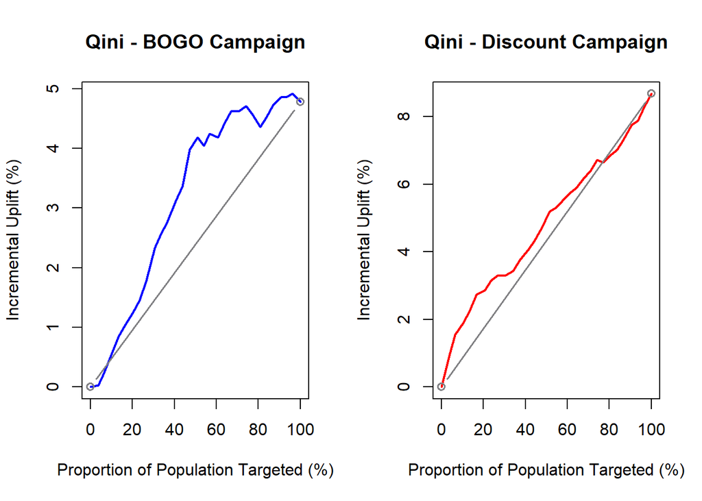

```
[1] 0.4608461
```

```r
# Plotar o gráfico de Qini para a campanha Discount usando o modelo Inter Uplift
plot(performance_inter_uplift_discount, type = "l", lwd = 2, col="red", main="Qini - Discount Campaign")
```

```r
# Restaurar configuração padrão do par
par(mfrow=c(1,1))
```

```r
# Obtenha os valores máximos e mínimos dos dados para ambos os gráficos
max_value <- max(max(performance_inter_uplift_bogo$uplift), max(performance_inter_uplift_discount$uplift))
min_value <- min(min(performance_inter_uplift_bogo$uplift), min(performance_inter_uplift_discount$uplift))

# Configurando a área de plotagem para dois gráficos lado a lado
par(mfrow=c(1,2))

# Primeiro gráfico para BOGO
barplot(performance_inter_uplift_bogo, col="blue4", main="Variação Uplift Incremental - BOGO",
        ylim=c(min_value, max_value))
```

```
[1] 0.3563218
```

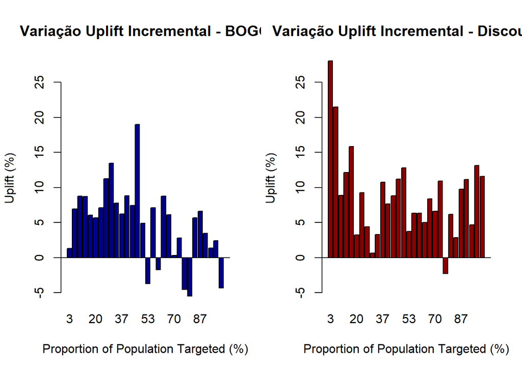

```
[1] 0.108046
```

```r
# Segundo gráfico para Discount
barplot(performance_inter_uplift_discount, col="red4", main="Variação Uplift Incremental - Discount",
        ylim=c(min_value, max_value))
```

```r
# Restaurar configuração padrão do par
par(mfrow=c(1,1))
```

## Conclusão:

Apesar das campanhas de marketing voltadas para promoção de disconto terem um resultado cumulativo melhor as campanhas de BOGO apresentam um desempenho uplift melhor, assim é necessário menor volume para um mesmo resultado para populações menores de marketing.

Desta forma para campanhas que buscam apenas o maior efeito sem necessidade de otimização podemos preferir uma campanha de desconto.

### Revisando distribuição de algumas variáveis com relação aos resultados:

#### Uso de Desconto:

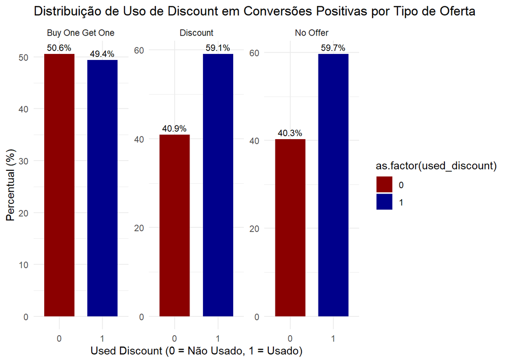

```r
# Preparação dos dados e cálculo das porcentagens para 'used_discount'
data_for_plot_discount <- vendas %>%
  filter(conversion == 1) %>%
  group_by(offer, used_discount) %>%
  summarise(Total = n(), .groups = 'drop') %>%
  group_by(offer) %>%
  mutate(Percent = (Total / sum(Total)) * 100)

# Criando o gráfico de barras para porcentagem de distribuição de 'used_discount' para conversões positivas por tipo de oferta
gg_discount_conversion_by_offer <- ggplot(data_for_plot_discount, aes(x = as.factor(used_discount), y = Percent, fill = as.factor(used_discount))) +
  geom_bar(stat = "identity", position = position_dodge(), width = 0.7) +
  geom_text(aes(label = sprintf("%.1f%%", Percent)),
            position = position_dodge(width = 0.7), vjust = -0.5, size = 3) +
  labs(title = "Distribuição de Uso de Discount em Conversões Positivas por Tipo de Oferta",
       x = "Used Discount (0 = Não Usado, 1 = Usado)",
       y = "Percentual (%)") +
  facet_wrap(~ offer, scales = "free_y") +
  scale_fill_manual(values = c("0" = "red4", "1" = "blue4")) +
  theme_minimal()

# Imprimir o gráfico
print(gg_discount_conversion_by_offer)
```

#### Uso de BOGO:

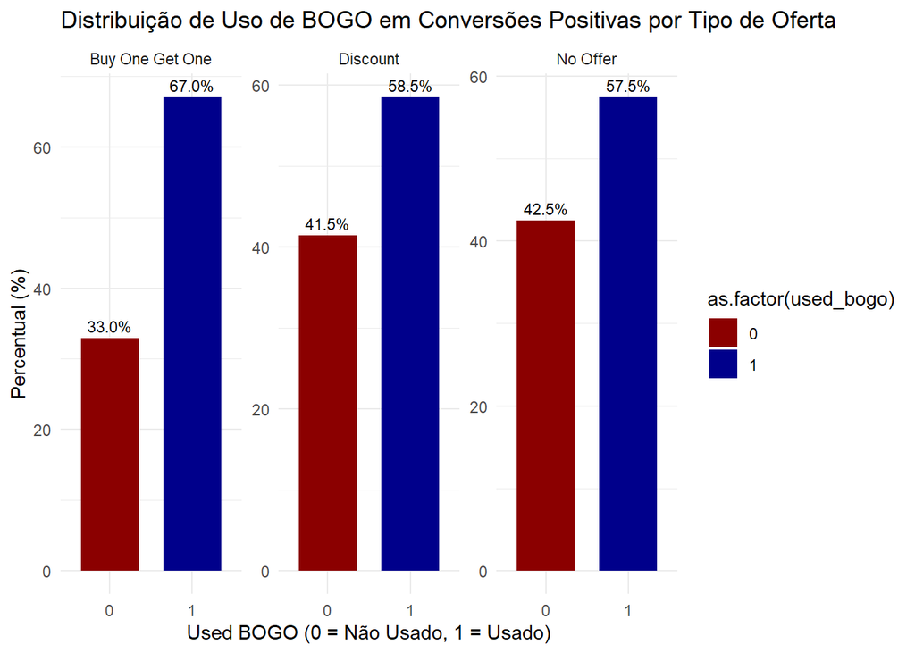

```r
# Preparação dos dados e cálculo das porcentagens de conversão para 'used_bogo'
data_for_plot_bogo <- vendas %>%
  filter(conversion == 1) %>%
  group_by(offer, used_bogo) %>%
  summarise(Total = n(), .groups = 'drop') %>%
  group_by(offer) %>%
  mutate(Percent = (Total / sum(Total)) * 100)

# Criando o gráfico de barras para porcentagem de distribuição de 'used_bogo' para conversões positivas por tipo de oferta
gg_bogo_conversion_by_offer <- ggplot(data_for_plot_bogo, aes(x = as.factor(used_bogo), y = Percent, fill = as.factor(used_bogo))) +
  geom_bar(stat = "identity", position = position_dodge(), width = 0.7) +
  geom_text(aes(label = sprintf("%.1f%%", Percent)),
            position = position_dodge(width = 0.7), vjust = -0.5, size = 3) +
  labs(title = "Distribuição de Uso de BOGO em Conversões Positivas por Tipo de Oferta",
       x = "Used BOGO (0 = Não Usado, 1 = Usado)",
       y = "Percentual (%)") +
  facet_wrap(~ offer, scales = "free_y") +
  scale_fill_manual(values = c("0" = "red4", "1" = "blue4")) +
  theme_minimal()

# Imprimir o gráfico
print(gg_bogo_conversion_by_offer)
```

#### Indicação de terceiros:

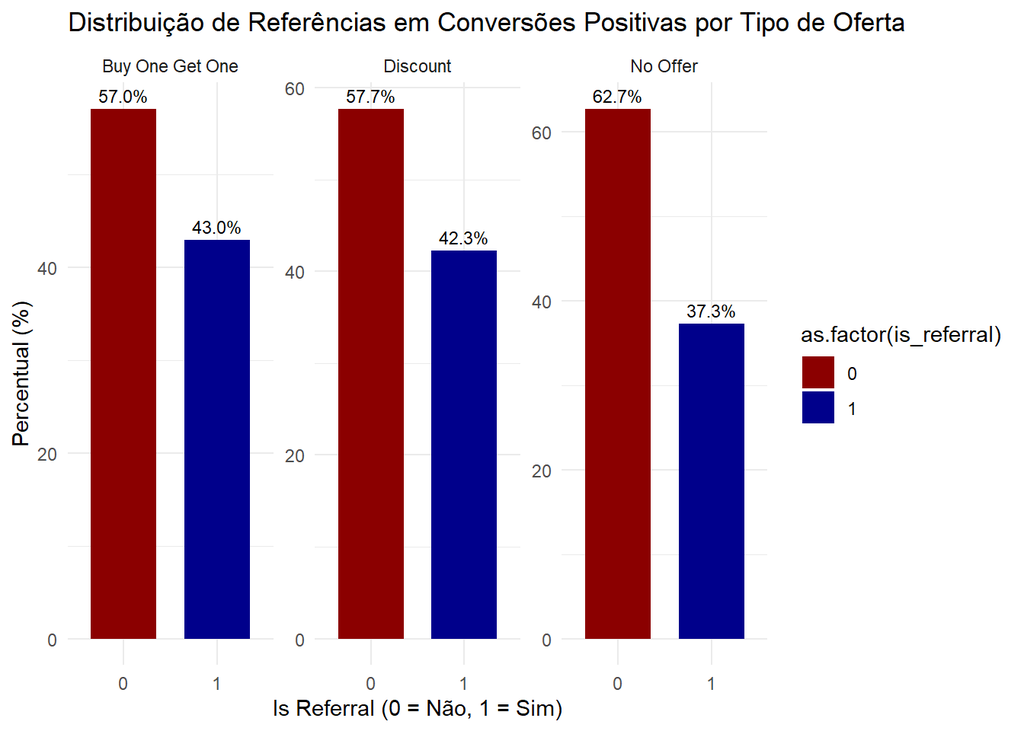

```r
# Preparação dos dados e cálculo das porcentagens de conversão para 'is_referral'
data_for_plot_referral <- vendas %>%
  filter(conversion == 1) %>%
  group_by(offer, is_referral) %>%
  summarise(Total = n(), .groups = 'drop') %>%
  group_by(offer) %>%
  mutate(Percent = (Total / sum(Total)) * 100)

# Criando o gráfico de barras para porcentagem de distribuição de 'is_referral' para conversões positivas por tipo de oferta
gg_referral_conversion_by_offer <- ggplot(data_for_plot_referral, aes(x = as.factor(is_referral), y = Percent, fill = as.factor(is_referral))) +
  geom_bar(stat = "identity", position = position_dodge(), width = 0.7) +
  geom_text(aes(label = sprintf("%.1f%%", Percent)),
            position = position_dodge(width = 0.7), vjust = -0.5, size = 3) +
  labs(title = "Distribuição de Referências em Conversões Positivas por Tipo de Oferta",
       x = "Is Referral (0 = Não, 1 = Sim)",
       y = "Percentual (%)") +
  facet_wrap(~ offer, scales = "free_y") +
  scale_fill_manual(values = c("0" = "red4", "1" = "blue4")) +
  theme_minimal()

# Imprimir o gráfico
print(gg_referral_conversion_by_offer)
```